# NOAA Storms Analysis

ACBLimehouse

6/18/2017

# Population Health and Economic Consequences of Various Meteorological Events

## Analysis Generated for Coursera Course: Reproducible Research

### Synopsis

For this project, I analyzed the NOAA Storms database for the Cousera Reproducible Research class. Taking the raw data, I cleaned up the event types to ensure that categories were being properly compared. Then I examined the meteorological event types across the entire data set. I found that, for population health, tornadoes have the greatest consequences while, for economics concerns, floods have the greatest consequences. As a major caveat, drought cause a greater amount of damage to crops but I have concerns, detailed below, about how these are being counted.

The following analysis was performed RStudio (1.0.136) and R (3.3.2).

### Data Processing

We begin the analysis by downloading and importing the Storms Data.

```r
dataURL <- "https://d396qusza40orc.cloudfront.net/repdata%2Fdata%2FStormData.csv.bz2"
documentationURL <- "https://d396qusza40orc.cloudfront.net/repdata%2Fpeer2_doc%2Fpd01016005curr.pdf"
documfile <- "StormDataDocumentation.PDF"
compfilename <- "StormData.csv.bz2"
filename <- "StormData.csv"
DataName <- "StormData"

library(R.utils)
library(dplyr)

## Download the Documentation for reference
if (!file.exists(documfile)) {
    download.file(documentationURL, documfile)
}

## Download the Data and Read it into the Global Environment
if (!file.exists(filename)) {
    if (!file.exists(compfilename)) {
        download.file(dataURL, compfilename, method = "curl")
    }
    bunzip2(compfilename, filename, remove = FALSE, skip = TRUE)
}
if (!exists(DataName)) {
    StormData <- read.csv(filename, header = TRUE)
}
```

After importing the data, we take a look at it to get a sense of how it needs to be cleaned in order to do a reasonable analysis. First, we look at the column names and top of the data set.

```r
names(StormData)
```

```
##  [1] "STATE__"    "BGN_DATE"   "BGN_TIME"   "TIME_ZONE"  "COUNTY"
##  [6] "COUNTYNAME" "STATE"      "EVTYPE"     "BGN_RANGE"  "BGN_AZI"
## [11] "BGN_LOCATI" "END_DATE"   "END_TIME"   "COUNTY_END" "COUNTYENDN"
## [16] "END_RANGE"  "END_AZI"    "END_LOCATI" "LENGTH"     "WIDTH"
## [21] "F"          "MAG"        "FATALITIES" "INJURIES"   "PROPDMG"
## [26] "PROPDMGEXP" "CROPDMG"    "CROPDMGEXP" "WFO"        "STATEOFFIC"
## [31] "ZONENAMES"  "LATITUDE"   "LONGITUDE"  "LATITUDE_E" "LONGITUDE_"
## [36] "REMARKS"    "REFNUM"
```

```r
head(StormData)
```

```
##   STATE__           BGN_DATE BGN_TIME TIME_ZONE COUNTY COUNTYNAME STATE
## 1       1  4/18/1950 0:00:00     0130       CST     97     MOBILE    AL
## 2       1  4/18/1950 0:00:00     0145       CST      3    BALDWIN    AL
## 3       1  2/20/1951 0:00:00     1600       CST     57    FAYETTE    AL
## 4       1   6/8/1951 0:00:00     0900       CST     89    MADISON    AL
## 5       1 11/15/1951 0:00:00     1500       CST     43    CULLMAN    AL
## 6       1 11/15/1951 0:00:00     2000       CST     77 LAUDERDALE    AL
##    EVTYPE BGN_RANGE BGN_AZI BGN_LOCATI END_DATE END_TIME COUNTY_END
## 1 TORNADO         0                                               0
## 2 TORNADO         0                                               0
## 3 TORNADO         0                                               0
## 4 TORNADO         0                                               0
## 5 TORNADO         0                                               0
## 6 TORNADO         0                                               0
##   COUNTYENDN END_RANGE END_AZI END_LOCATI LENGTH WIDTH F MAG FATALITIES
```

[output cut: 20 more lines]

Then, we take a look at the top 15 most frequent event types in NOAA’s Storm Data.

```r
event_types <- as.data.frame(table(StormData$EVTYPE))
event_types <- event_types[order(-event_types$Freq), ]
head(event_types, 15)
```

```
##                   Var1   Freq
## 244               HAIL 288661
## 856          TSTM WIND 219940
## 760  THUNDERSTORM WIND  82563
## 834            TORNADO  60652
## 153        FLASH FLOOD  54277
## 170              FLOOD  25326
## 786 THUNDERSTORM WINDS  20843
## 359          HIGH WIND  20212
## 464          LIGHTNING  15754
## 310         HEAVY SNOW  15708
## 290         HEAVY RAIN  11723
## 972       WINTER STORM  11433
## 978     WINTER WEATHER   7026
## 216       FUNNEL CLOUD   6839
## 490   MARINE TSTM WIND   6175
```

```r
rm(event_types)
```

This tells us that there are many event type names that overlap in commonly understood categories. Some of these categories include:  
- Cold Weather;  
- Tornados;  
- Nautical events including high seas, heavy waves, etc;  
- Tropical Storms including typhoons, hurricanes, and tropical depressions;  
- Wind; and,  
- Flood

So, with that in mind, we go about combining the event types using R’s grepl. **Note**: in cases of event type categories that include “/”, “&”, or “and”, those event types are collapsed into a single value named “Multiple Event”. This “Multiple Event” category is included in the analysis for completeness but it should be understood that it overlaps most of the other singular event types.

```r
StormData$EVTYPE <- as.character(StormData$EVTYPE)
StormData$EVTYPE[grepl("/|&|and", StormData$EVTYPE, ignore.case = TRUE)] <- "Multiple Event"
StormData$EVTYPE[grepl("volc", StormData$EVTYPE, ignore.case = TRUE)] <- "Volcano"
StormData$EVTYPE[grepl("DROUGHT", StormData$EVTYPE, ignore.case = TRUE)] <- "Drought"
StormData$EVTYPE[grepl("tsunami", StormData$EVTYPE, ignore.case = TRUE)] <- "Tsnumai"
StormData$EVTYPE[grepl("LIGHTNING", StormData$EVTYPE, ignore.case = TRUE)] <- "Lightning"
StormData$EVTYPE[grepl("Avalanc*", StormData$EVTYPE, ignore.case = TRUE)] <- "Avalanche"
StormData$EVTYPE[grepl("*Fog", StormData$EVTYPE, ignore.case = TRUE)] <- "Fog"
StormData$EVTYPE[grepl("wind|wnd", StormData$EVTYPE, ignore.case = TRUE)] <- "Wind"
StormData$EVTYPE[grepl("funnel|tornado", StormData$EVTYPE, ignore.case = TRUE)] <- "Tornado"
StormData$EVTYPE[grepl("glaze", StormData$EVTYPE, ignore.case = TRUE)] <- "Glaze"
StormData$EVTYPE[grepl("hail", StormData$EVTYPE, ignore.case = TRUE)] <- "Hail"
StormData$EVTYPE[grepl("dust", StormData$EVTYPE, ignore.case = TRUE)] <- "Dust"
StormData$EVTYPE[grepl("flood|*rising*|high water", StormData$EVTYPE, ignore.case = TRUE)] <- "Flood"
StormData$EVTYPE[grepl("ic(e|y)", StormData$EVTYPE, ignore.case = TRUE)] <- "Ice"
StormData$EVTYPE[grepl("fire|smoke", StormData$EVTYPE, ignore.case = TRUE)] <- "Fire"
StormData$EVTYPE[grepl("thunder", StormData$EVTYPE, ignore.case = TRUE)] <- "Non-Tropical Storm"
StormData$EVTYPE[grepl("Coastal*|Non-Tropical*|microburst", StormData$EVTYPE,
    ignore.case = TRUE)] <- "Non-Tropical Storm"
StormData$EVTYPE[grepl("slide|eros", StormData$EVTYPE, ignore.case = TRUE)] <- "Erosion"
StormData$EVTYPE[grepl("rain", StormData$EVTYPE, ignore.case = TRUE)] <- "Rain"
StormData$EVTYPE[grepl("freez|cold|snow|chill|winter|blizzard|sleet|glaze|frost|hypothermia|wintry*|low temp*|mixed precip|ice",
    StormData$EVTYPE, ignore.case = TRUE)] <- "Cold Weather"
StormData$EVTYPE[grepl("TROPICAL.Storm|typhoon|*depression", StormData$EVTYPE,
    ignore.case = TRUE)] <- "Tropical Storm"
StormData$EVTYPE[grepl("(hurri|opal)", StormData$EVTYPE, ignore.case = TRUE)] <- "Tropical Storm"
StormData$EVTYPE[grepl("RIP CURREN(T|TS)", StormData$EVTYPE, ignore.case = TRUE)] <- "Rip Current"
StormData$EVTYPE[grepl("*Current|*SURF|*SEAS|marine*|*swells|*waves|waterspout|*tide",
    StormData$EVTYPE, ignore.case = TRUE)] <- "Nautical"
StormData$EVTYPE[grepl("heat", StormData$EVTYPE, ignore.case = TRUE)] <- "Heat"
StormData$EVTYPE[grepl("Storm SURGE", StormData$EVTYPE, ignore.case = TRUE)] <- "Storm Surge"
```

Now we can take a look at the Property Damage and Crop Damage Exponents to get a sense of they are used in the data set. We start by examining and then transforming the Property Damage Exponents variable.

```r
## Clean the Property and Crop Damage Data
unique(StormData$PROPDMGEXP)
```

```
##  [1] K M   B m + 0 5 6 ? 4 2 3 h 7 H - 1 8
## Levels:  - ? + 0 1 2 3 4 5 6 7 8 B h H K m M
```

```r
## Transform the property damage exponents into numeric values
StormData$PROPDMG[StormData$PROPDMGEXP == "K"] <- StormData$PROPDMG[StormData$PROPDMGEXP ==
    "K"] * 1000
StormData$PROPDMG[StormData$PROPDMGEXP == "M"] <- StormData$PROPDMG[StormData$PROPDMGEXP ==
    "M"] * (10^6)
StormData$PROPDMG[StormData$PROPDMGEXP == "H"] <- StormData$PROPDMG[StormData$PROPDMGEXP ==
    "H"] * 100
StormData$PROPDMG[StormData$PROPDMGEXP == "h"] <- StormData$PROPDMG[StormData$PROPDMGEXP ==
    "h"] * 100
StormData$PROPDMG[StormData$PROPDMGEXP == ""] <- StormData$PROPDMG[StormData$PROPDMGEXP ==
    ""] * 1
StormData$PROPDMG[StormData$PROPDMGEXP == "B"] <- StormData$PROPDMG[StormData$PROPDMGEXP ==
    "B"] * (10^9)
StormData$PROPDMG[StormData$PROPDMGEXP == "m"] <- StormData$PROPDMG[StormData$PROPDMGEXP ==
    "m"] * (10^6)
StormData$PROPDMG[StormData$PROPDMGEXP == "0"] <- StormData$PROPDMG[StormData$PROPDMGEXP ==
    "0"] * 1
StormData$PROPDMG[StormData$PROPDMGEXP == "1"] <- StormData$PROPDMG[StormData$PROPDMGEXP ==
    "1"] * 10
StormData$PROPDMG[StormData$PROPDMGEXP == "2"] <- StormData$PROPDMG[StormData$PROPDMGEXP ==
    "2"] * 100
StormData$PROPDMG[StormData$PROPDMGEXP == "3"] <- StormData$PROPDMG[StormData$PROPDMGEXP ==
    "3"] * 1000
StormData$PROPDMG[StormData$PROPDMGEXP == "4"] <- StormData$PROPDMG[StormData$PROPDMGEXP ==
    "4"] * (10^4)
StormData$PROPDMG[StormData$PROPDMGEXP == "5"] <- StormData$PROPDMG[StormData$PROPDMGEXP ==
    "5"] * (10^5)
StormData$PROPDMG[StormData$PROPDMGEXP == "6"] <- StormData$PROPDMG[StormData$PROPDMGEXP ==
    "6"] * (10^6)
StormData$PROPDMG[StormData$PROPDMGEXP == "7"] <- StormData$PROPDMG[StormData$PROPDMGEXP ==
    "7"] * (10^7)
StormData$PROPDMG[StormData$PROPDMGEXP == "8"] <- StormData$PROPDMG[StormData$PROPDMGEXP ==
    "8"] * (10^8)
StormData$PROPDMG[StormData$PROPDMGEXP == "+"] <- 0
StormData$PROPDMG[StormData$PROPDMGEXP == "-"] <- 0
StormData$PROPDMG[StormData$PROPDMGEXP == "?"] <- 0
head(StormData[, c("EVTYPE", "PROPDMG", "PROPDMGEXP")])
```

```
##    EVTYPE PROPDMG PROPDMGEXP
## 1 Tornado   25000          K
## 2 Tornado    2500          K
## 3 Tornado   25000          K
## 4 Tornado    2500          K
## 5 Tornado    2500          K
## 6 Tornado    2500          K
```

```r
## Crop Damage transformation
StormData$CROPDMG[StormData$CROPDMGEXP == "M"] <- StormData$CROPDMG[StormData$CROPDMGEXP ==
    "M"] * (10^6)
StormData$CROPDMG[StormData$CROPDMGEXP == "K"] <- StormData$CROPDMG[StormData$CROPDMGEXP ==
    "K"] * 1000
StormData$CROPDMG[StormData$CROPDMGEXP == "m"] <- StormData$CROPDMG[StormData$CROPDMGEXP ==
    "m"] * (10^6)
StormData$CROPDMG[StormData$CROPDMGEXP == "B"] <- StormData$CROPDMG[StormData$CROPDMGEXP ==
    "B"] * (10^9)
StormData$CROPDMG[StormData$CROPDMGEXP == "k"] <- StormData$CROPDMG[StormData$CROPDMGEXP ==
    "k"] * 1000
StormData$CROPDMG[StormData$CROPDMGEXP == "0"] <- StormData$CROPDMG[StormData$CROPDMGEXP ==
    "0"] * 1
StormData$CROPDMG[StormData$CROPDMGEXP == "2"] <- StormData$CROPDMG[StormData$CROPDMGEXP ==
    "2"] * 100
StormData$CROPDMG[StormData$CROPDMGEXP == ""] <- StormData$CROPDMG[StormData$CROPDMGEXP ==
    ""] * 1
StormData$CROPDMG[StormData$CROPDMGEXP == "?"] <- 0
head(StormData[, c("EVTYPE", "CROPDMG", "CROPDMGEXP")])
```

```
##    EVTYPE CROPDMG CROPDMGEXP
## 1 Tornado       0
## 2 Tornado       0
## 3 Tornado       0
## 4 Tornado       0
## 5 Tornado       0
## 6 Tornado       0
```

We’re now in a position to take a look at the data and answer two questions:  
1. **Across the US, which event typs (EVTYPE variable) are most harmful to population health?**  
2. **Across the US, which event types have the greatest economic conseqences?**

## Section Three: Data Analysis and Results

### Public Health Consequences

Let’s address the population health consequences first. Usually, when we think of public health we include chronic and acute disease, injury, and fatalities. Unfortunately, NOAA’s data set does not include the disease consequences of crop damage, dust, flooding, etc. Instead, the public health consequences of meteorological events are reduced only to injuries and fatalities.

So, we aggregate the top 10 meteorological causes of both.

```r
## Fatalities aggregation
fatal <- aggregate(FATALITIES ~ EVTYPE, data = StormData, FUN = sum, na.rm = TRUE)
fatal <- fatal[with(fatal, order(-FATALITIES)), ]
fatal <- head(fatal, 10)
print(fatal)
```

```
##             EVTYPE FATALITIES
## 160        Tornado       5633
## 36            Heat       3110
## 32           Flood       1490
## 182           Wind       1207
## 8     Cold Weather        829
## 50       Lightning        817
## 57        Nautical        733
## 56  Multiple Event        597
## 6        Avalanche        225
## 162 Tropical Storm        144
```

```r
## Injuries aggregation
injury <- aggregate(INJURIES ~ EVTYPE, data = StormData, FUN = sum, na.rm = TRUE)
injury <- injury[with(injury, order(-INJURIES)), ]
injury <- head(injury, 10)
print(injury)
```

```
##             EVTYPE INJURIES
## 160        Tornado    91368
## 182           Wind    11299
## 36            Heat     9209
## 32           Flood     8582
## 8     Cold Weather     6500
## 50       Lightning     5231
## 56  Multiple Event     2372
## 35            Hail     1371
## 33             Fog     1076
## 30            Fire     1063
```

As you can see, Tornados are the event type that causes the most fatalities and injuries across the whole of the US. Now, let’s take a look at this graphically.

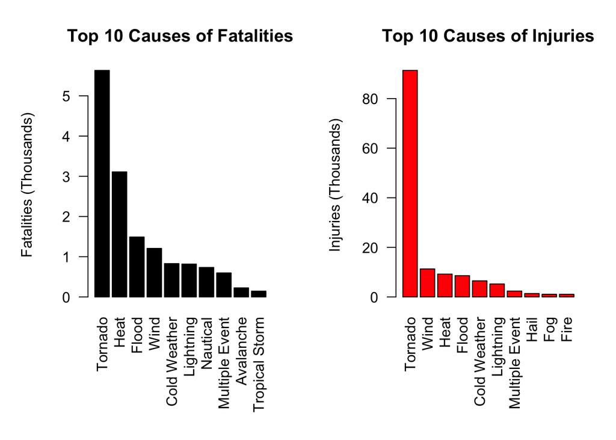

```r
## plot the graph showing the top 10 fatalities and injuries
par(mfrow = c(1, 2), mar = c(8, 5, 4, 2))
barplot(fatal$FATALITIES/(10^3), names.arg = fatal$EVTYPE, las = 2, col = "black",
    ylab = "Fatalities (Thousands)", main = "Top 10 Causes of Fatalities")
barplot(injury$INJURIES/(10^3), names.arg = injury$EVTYPE, las = 2, col = "red",
    ylab = "Injuries (Thousands)", main = "Top 10 Causes of Injuries")
```

Again, Tornados are far and away the most important cause of fatalities and injuries in the US. This makes some sense as, according to NOAA, more than 1,200 tornadoes strike the US every year. See [here.](http://www.nssl.noaa.gov/education/svrwx101/tornadoes/)

### Economic Consequences

Now we can take a look at the economic consequences of the meteorological events in the NOAA data set. These consequences include property damage and crop damage. Why, you might ask, are these separated? I don’t know. My guess is that the data for these are tracked by separate agencies of the US government (for crop data, it’s probably the [USDA](https://usdasearch.usda.gov/search?utf8=%E2%9C%93&affiliate=usda&query=crop+damage+due+to+weather)).

Regardless, let’s perform the same aggregation as before on property and crop damage and see what happens.

```r
## Economic Consequences
prop <- aggregate(PROPDMG ~ EVTYPE, data = StormData, FUN = sum, na.rm = TRUE)
prop <- prop[with(prop, order(-PROPDMG)), ]
prop <- head(prop, 10)
print(prop)
```

```
##             EVTYPE      PROPDMG
## 32           Flood 167687425750
## 56  Multiple Event  80750793263
## 160        Tornado  56952401466
## 92     Storm Surge  43323536000
## 162 Tropical Storm  24883324710
## 182           Wind  17670751724
## 35            Hail  15977048513
## 8     Cold Weather  12463841361
## 30            Fire   5494879000
## 14         Drought   1046306000
```

```r
crop <- aggregate(CROPDMG ~ EVTYPE, data = StormData, FUN = sum, na.rm = TRUE)
crop <- crop[with(crop, order(-CROPDMG)), ]
crop <- head(crop, 10)
print(crop)
```

```
##             EVTYPE     CROPDMG
## 14         Drought 13972616000
## 32           Flood 12171142100
## 8     Cold Weather  7557271900
## 56  Multiple Event  4202621910
## 162 Tropical Storm  3611361000
## 35            Hail  3046887473
## 182           Wind  1963523138
## 36            Heat   904413500
## 65            Rain   804652800
## 160        Tornado   414961520
```

As you can see, Floods cause far and away more property damage than any other type of event while drought, which can last for years, causes more damage to crops. However, this may not be a fair analysis since, as I said, droughts take place over a long period of time, while floods, which cause almost as much damage, take place over a comparatively short time scale.

To wrap up, let’s show this graphically:

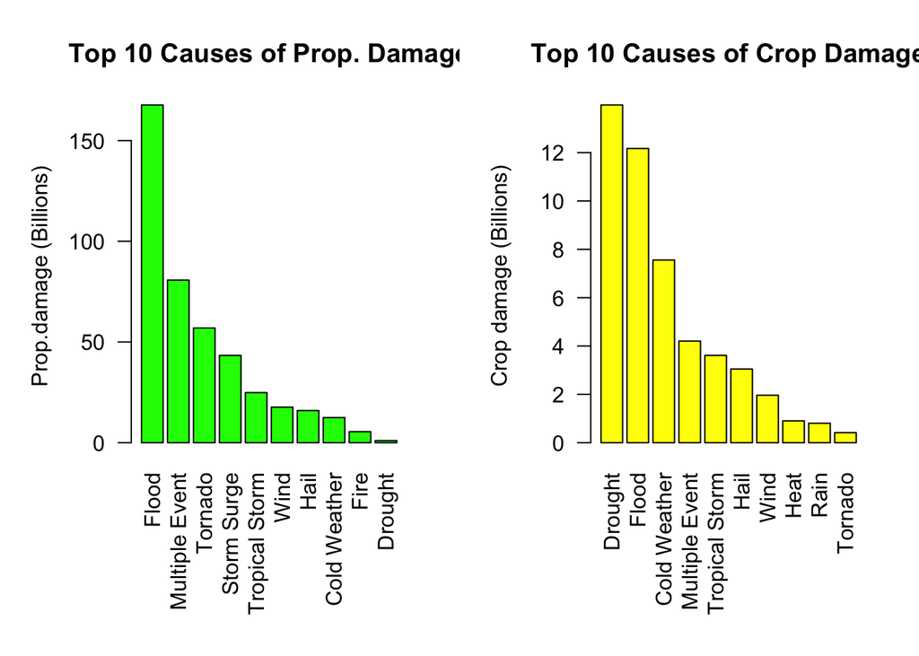

```r
## Economic Results
par(mfrow = c(1, 2), mar = c(8, 5, 4, 2))

## plot the graph showing the top 10 property and crop damages
barplot(prop$PROPDMG/(10^9), names.arg = prop$EVTYPE, las = 2, col = "green",
    ylab = "Prop.damage (Billions)", main = "Top 10 Causes of Prop. Damage")
barplot(crop$CROPDMG/(10^9), names.arg = crop$EVTYPE, las = 2, col = "yellow",
    ylab = "Crop damage (Billions)", main = "Top 10 Causes of Crop Damage")
```

*There you have it.*

## Conclusions

To sum up this analysis, here are three conclusions and a caveat:  
1 Tornados are bad news and cause the most deaths and injuries of any kind of weather in the US.  
2 Floods, while they don’t kill and maim as many people, are not great for property or crops.  
3 Finally, Drought also quite terrible for crops but may be less important than appears because of a time-scale issue.

The caveat is this: The time-scale issue may not actually be an issue since we have measured the consequences of these events across a comparable time period. However, my sense is that due to the slow moving nature of draught it is easier to measure the damage done to crops from a baseline year-over-year average.

Questions, Comments, Elucidations of measuring crop damage due to fire or flood? Email me here or check out the git hub page where you can find the R code and Rmd files I used to generate the analysis [here](https://github.com/acblimehouse/RR-WK4-CP-2).